# Purpose

Create an input file with the proper Operational Taxonomic Units (OTUs), attributes, and stream class for each calculation. This function performs three steps to the input file:

1. “Translates” the original TaxonID to the proper OTU based on the selected calculation.
2. Appends the Michigan taxa attributes, which include phylogenetic data and traits.
3. Appends the correct Stream Class based on site coordinates.

The ‘taxa translator’ and attribute tables are based on biomonitoring data from Michigan streams and will be updated regularly.

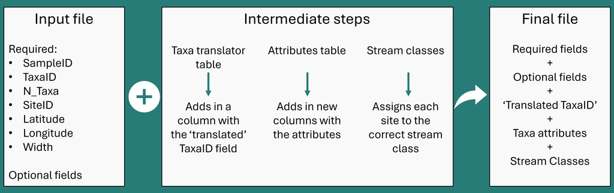

Filebuilder Taxa Translate steps.

# Input File

There are multiple fields that the user is required to provide:

SampleID and TaxaID will be used to match the input file with the taxa translator table and attributes table. N_Taxa will be summarized in cases when more than one original TaxaID are translated to a single TaxonID.

SiteID, Latitude, Longitude, and Stream Width are all necessary for Stream Class assignment. Note, that these fields must be complete for all rows of the input file, otherwise, accidental duplication may occur which will likely result in a malfunction or cause the app to crash.

It is acceptable for your input file to have the fields described above named differently. Click on the drop-down menus. The list of fields in your input file will appear. Select the correct column headings.

**Other required fields**

Long-format files: Other required fields and any optional fields that should be carried through into the output file (e.g., waterbody name, collection date, etc.) should be specified by clicking on the ‘Columns to keep in output’ box. The list of fields in your input file will appear. Click on the fields that you want to include. If you change your mind and want to remove a field, click on it and hit ‘delete.’ IMPORTANT: Do not add any of the required fields to this box as they are already included from the drop-downs above.

Wide-format files: Specify all non-taxa columns in the ‘Columns to keep in output’. IMPORTANT: Do not add any of the required fields to this box as they are already included from the drop-downs above. The data are transformed into long-format and all fields not selected (in the above boxes) are assumed to be taxa. Failing to specify all non-taxa columns will likely cause the app to crash.

# Test File

The EGLE Input Test File can be used as a guide for your own input file: [File Builder Test File](https://raw.githubusercontent.com/Blocktt/ShinyAppDocuments/refs/heads/main/MIEGLEtools/Example_Files/MI_EGLE_FileBuilder_Input_20241203.csv).